# 9장 데이터 분석 프로젝트 - 한국인의 삶을 파악하라

# 한국복지패널 데이터 분석

- 한국보건사회연구원에서 우리나가 가구의 경제활동을 연구한 데이터
- 전국 7,000여 가구를 선정하여 2006년 부터 매년 추적 조사한 자료
- 경제활동, 생활실태, 복지욕구 등 천여개 변수로 구성됨
- 통계 패키지 SPSS 전용 파일
- bit.ly/easypy_91

## 학습 목표

### 09-1 한국복지패널 데이터 분석 준비하기

### 09-6 직업별 월급 차이 - 어떤 직업이 월급을 가장 많이 받을까?

### 09-7 성별 직업 빈도 - 성별로 어떤 직업이 가장 많을까?

### 09-8 종교 유무에 따른 이혼율 - 종교가 있으면 이혼을 덜 할까?

### 09-9 지역별 연령대 비율 - 어느 지역에 노년층이 많을까?

# 9-1 한국복지패널 데이터 분석 준비하기

### Lab 1 : 데이터 분석 준비하기

1. 데이터 준비하기
- Koweps_hpwc14_2019_beta2.sav vkdlf ekdnsfhem
- 202년 발간된 복지패널 데이터로, 6331가구, 14,418명 정보를 담고 있음
2. 패키지 설치 및 로드하기
- 실습에 사용항 데이터 파일은 통계 분석 패키지인 SPAA 전용 파일임
- pyreadstat 패키지를 설치하면 SPSS, SAS, STATA등 다양한 통계 분석 소프트웨어 데이터 파일을 불러 올 수 있음
- pip install pyreadstat

```python
import pandas as pd
import numpy as np
import seaborn as sns
```

```python
pip install pyreadstat
```

3. 데이터 불러오기
- pd.read_spss()로 데이터 불러오기
- df.copy()로 복사본을 만들어 분석에 활용함

```python
# 데이터 불러오기
raw_welfare = pd.read_spss('Koweps_hpwc14_2019_beta2.sav')
```

```python
# 복사본 만들기
welfare = raw_welfare.copy()
```

```python
welfare.head()
```

|  | h14_id | h14_ind | h14_sn | h14_merkey | h_new | h14_cobf | p14_wsc | p14_wsl | p14_wgc | p14_wgl | ... | wc14_64 | wc14_65 | wc14_5aq4 | wc14_5aq5 | wc14_5aq6 | h14_pers_income1 | h14_pers_income2 | h14_pers_income3 | h14_pers_income4 | h14_pers_income5 |
| --- | --- | --- | --- | --- | --- | --- | --- | --- | --- | --- | --- | --- | --- | --- | --- | --- | --- | --- | --- | --- | --- |
| 0 | 2.0 | 1.0 | 1.0 | 20101.0 | 0.0 | NaN | 0.291589 | 0.291589 | 1307.764781 | 1307.764781 | ... | NaN |  | NaN | NaN | NaN | NaN | NaN | NaN | 0.0 | NaN |
| 1 | 3.0 | 1.0 | 1.0 | 30101.0 | 0.0 | NaN | 0.419753 | 0.419753 | 1882.570960 | 1882.570960 | ... | NaN |  | NaN | NaN | NaN | NaN | NaN | NaN | 0.0 | NaN |
| 2 | 4.0 | 1.0 | 1.0 | 40101.0 | 0.0 | NaN | 0.265263 | 0.265980 | 1189.691668 | 1192.908537 | ... | NaN |  | NaN | NaN | NaN | NaN | 1284.0 | NaN | 0.0 | NaN |
| 3 | 6.0 | 1.0 | 1.0 | 60101.0 | 0.0 | NaN | 0.494906 | 0.495941 | 2219.630833 | 2224.273816 | ... | 1.0 | . | 2.0 | 4.0 | 4.0 | 2304.0 | NaN | 1800.0 | 0.0 | NaN |
| 4 | 6.0 | 1.0 | 1.0 | 60101.0 | 0.0 | NaN | 1.017935 | 1.017935 | 4565.389177 | 4565.389177 | ... | 1.0 | . | 1.0 | 5.0 | 2.0 | NaN | NaN | NaN | 0.0 | NaN |

5 rows × 830 columns

4. 데이터 검토하기
- 데이터의 특성을 살펴보기
- 행, 열 개수
- 변수 속성
- 요약 통계양

```python
welfare.head()
```

|  | h14_id | h14_ind | h14_sn | h14_merkey | h_new | h14_cobf | p14_wsc | p14_wsl | p14_wgc | p14_wgl | ... | wc14_64 | wc14_65 | wc14_5aq4 | wc14_5aq5 | wc14_5aq6 | h14_pers_income1 | h14_pers_income2 | h14_pers_income3 | h14_pers_income4 | h14_pers_income5 |
| --- | --- | --- | --- | --- | --- | --- | --- | --- | --- | --- | --- | --- | --- | --- | --- | --- | --- | --- | --- | --- | --- |
| 0 | 2.0 | 1.0 | 1.0 | 20101.0 | 0.0 | NaN | 0.291589 | 0.291589 | 1307.764781 | 1307.764781 | ... | NaN |  | NaN | NaN | NaN | NaN | NaN | NaN | 0.0 | NaN |
| 1 | 3.0 | 1.0 | 1.0 | 30101.0 | 0.0 | NaN | 0.419753 | 0.419753 | 1882.570960 | 1882.570960 | ... | NaN |  | NaN | NaN | NaN | NaN | NaN | NaN | 0.0 | NaN |
| 2 | 4.0 | 1.0 | 1.0 | 40101.0 | 0.0 | NaN | 0.265263 | 0.265980 | 1189.691668 | 1192.908537 | ... | NaN |  | NaN | NaN | NaN | NaN | 1284.0 | NaN | 0.0 | NaN |
| 3 | 6.0 | 1.0 | 1.0 | 60101.0 | 0.0 | NaN | 0.494906 | 0.495941 | 2219.630833 | 2224.273816 | ... | 1.0 | . | 2.0 | 4.0 | 4.0 | 2304.0 | NaN | 1800.0 | 0.0 | NaN |
| 4 | 6.0 | 1.0 | 1.0 | 60101.0 | 0.0 | NaN | 1.017935 | 1.017935 | 4565.389177 | 4565.389177 | ... | 1.0 | . | 1.0 | 5.0 | 2.0 | NaN | NaN | NaN | 0.0 | NaN |

5 rows × 830 columns

```python
welfare.tail()
```

|  | h14_id | h14_ind | h14_sn | h14_merkey | h_new | h14_cobf | p14_wsc | p14_wsl | p14_wgc | p14_wgl | ... | wc14_64 | wc14_65 | wc14_5aq4 | wc14_5aq5 | wc14_5aq6 | h14_pers_income1 | h14_pers_income2 | h14_pers_income3 | h14_pers_income4 | h14_pers_income5 |
| --- | --- | --- | --- | --- | --- | --- | --- | --- | --- | --- | --- | --- | --- | --- | --- | --- | --- | --- | --- | --- | --- |
| 14413 | 9800.0 | 7.0 | 1.0 | 98000701.0 | 1.0 | NaN | NaN | NaN | NaN | NaN | ... | NaN |  | NaN | NaN | NaN | NaN | NaN | NaN | 0.0 | NaN |
| 14414 | 9800.0 | 7.0 | 1.0 | 98000701.0 | 1.0 | NaN | NaN | NaN | NaN | NaN | ... | NaN |  | NaN | NaN | NaN | NaN | NaN | NaN | 0.0 | NaN |
| 14415 | 9800.0 | 7.0 | 1.0 | 98000701.0 | 1.0 | NaN | NaN | NaN | NaN | NaN | ... | NaN |  | NaN | NaN | NaN | NaN | 208.0 | NaN | 0.0 | NaN |
| 14416 | 9800.0 | 7.0 | 1.0 | 98000701.0 | 1.0 | NaN | NaN | NaN | NaN | NaN | ... | 5.0 | . | 4.0 | 3.0 | 3.0 | NaN | 1200.0 | NaN | 0.0 | NaN |
| 14417 | 9800.0 | 7.0 | 1.0 | 98000701.0 | 1.0 | NaN | NaN | NaN | NaN | NaN | ... | NaN |  | NaN | NaN | NaN | NaN | NaN | NaN | 0.0 | NaN |

5 rows × 830 columns

```python
# 행과 열 개수 출력
welfare.shape
```

```
(14418, 830)
```

```python
# 변수 속성 출력
welfare.info()
```

```
<class 'pandas.core.frame.DataFrame'>
RangeIndex: 14418 entries, 0 to 14417
Columns: 830 entries, h14_id to h14_pers_income5
dtypes: float64(826), object(4)
memory usage: 91.3+ MB
```

```python
# 요약 통계량
welfare.describe()
```

|  | h14_id | h14_ind | h14_sn | h14_merkey | h_new | h14_cobf | p14_wsc | p14_wsl | p14_wgc | p14_wgl | ... | wc14_63 | wc14_64 | wc14_5aq4 | wc14_5aq5 | wc14_5aq6 | h14_pers_income1 | h14_pers_income2 | h14_pers_income3 | h14_pers_income4 | h14_pers_income5 |
| --- | --- | --- | --- | --- | --- | --- | --- | --- | --- | --- | --- | --- | --- | --- | --- | --- | --- | --- | --- | --- | --- |
| count | 14418.000000 | 14418.000000 | 14418.000000 | 1.441800e+04 | 14418.000000 | 121.000000 | 11513.000000 | 11513.000000 | 11513.000000 | 11513.000000 | ... | 2027.000000 | 2027.000000 | 2027.000000 | 2027.000000 | 2027.000000 | 2659.000000 | 3331.000000 | 989.000000 | 14418.000000 | 715.000000 |
| mean | 4672.108406 | 3.121723 | 1.004855 | 4.672140e+07 | 0.201484 | 2.256198 | 1.000000 | 1.000000 | 4484.952219 | 4484.952541 | ... | 3.211643 | 3.743957 | 3.513567 | 4.100641 | 3.233350 | 4141.380594 | 1389.440408 | 3457.835187 | 2.038702 | 1183.292308 |
| std | 2792.998128 | 3.297963 | 0.143205 | 2.793014e+07 | 0.401123 | 1.675952 | 0.906021 | 1.016782 | 4063.459773 | 4560.218659 | ... | 2.174768 | 3.138629 | 1.045929 | 0.937712 | 1.289456 | 2583.755449 | 1211.910836 | 6619.516319 | 32.965477 | 2147.418274 |
| min | 2.000000 | 1.000000 | 1.000000 | 2.010100e+04 | 0.000000 | 1.000000 | 0.001998 | 0.000000 | 8.960093 | 0.000000 | ... | 1.000000 | 1.000000 | 1.000000 | 1.000000 | 1.000000 | 0.000000 | 0.000000 | -47000.000000 | 0.000000 | -10600.000000 |
| 25% | 2356.000000 | 1.000000 | 1.000000 | 2.356030e+07 | 0.000000 | 1.000000 | 0.341814 | 0.269286 | 1533.021553 | 1207.736094 | ... | 1.000000 | 2.000000 | 3.000000 | 4.000000 | 2.000000 | 2448.000000 | 391.500000 | 1000.000000 | 0.000000 | 206.000000 |
| 50% | 4535.000000 | 1.000000 | 1.000000 | 4.535010e+07 | 0.000000 | 2.000000 | 0.726304 | 0.704045 | 3257.436901 | 3157.609630 | ... | 3.000000 | 3.000000 | 4.000000 | 4.000000 | 3.000000 | 3540.000000 | 1116.000000 | 2498.000000 | 0.000000 | 530.000000 |
| 75% | 6616.000000 | 7.000000 | 1.000000 | 6.616010e+07 | 0.000000 | 2.000000 | 1.366071 | 1.390045 | 6126.762919 | 6234.287538 | ... | 5.000000 | 5.000000 | 4.000000 | 5.000000 | 4.000000 | 5378.500000 | 2040.000000 | 4687.000000 | 0.000000 | 1295.000000 |
| max | 9800.000000 | 14.000000 | 9.000000 | 9.800070e+07 | 1.000000 | 7.000000 | 4.727006 | 5.790039 | 21200.393903 | 25968.049029 | ... | 9.000000 | 99.000000 | 9.000000 | 9.000000 | 9.000000 | 22700.000000 | 11500.000000 | 170000.000000 | 3000.000000 | 22644.000000 |

8 rows × 826 columns

5. 변수명 바꾸기
- 복지데이터와 같은 대규모 데이토는 변수의 수가 많고 변수명이 코드로 되어 있음
- 규모가 큰 조사 자료의 경우 데이터 특징을 설명한 코드북(codebook)을 함께 제공
- 코드북에는 변수명과 값의 의미가 설명되어 있음
- 복지 데이터 코드북 일부: Koweps_Codebook_2019.xlsl
- 7개 변수를 선정하여 분석함
  - (1단계) 변수검토 및 전처리
  - (2단계) 변수 간 관계 분석

```python
welfare = welfare.rename(
   columns = {'h14_g3'     : 'sex',             # 성별
              'h14_g4'     : 'birth',           # 생년
              'h14_g10'    : 'marriage_type',   # 결혼 유무
              'h14_g11'    : 'religion',        # 종교
              'p1402_8aq1' : 'income',          # 수입(연봉)
              'h14_eco9'   : 'code_job',        # 직업 분류
              'h14_reg7'   : 'code_region'      # 지역
             })
```

```python
# 성별로 몇명이 있는지 확인
# 성별 변수의 데이터 타입 확인
welfare['sex'].dtypes
```

```
dtype('float64')
```

```python
# 성별로 몇명이 있는지 확인
# 성별 분류별 빈도 수 구하기 (성별은 1, 2로 구성)
welfare['sex'].value_counts()
```

```
sex
2.0    7913
1.0    6505
Name: count, dtype: int64
```

- 성별 값에 대한 코드북 확인
- 여자 7913명, 남자 6505명
- 모름/무응답(9) 값은 없는 것으로 확인됨

| 값 | 내용 |
| --- | --- |
| 1 | 남자 |
| 2 | 여자 |
| 9 | 모름/무응답 |

```python
# 성별 항목 이름 부여
welfare['sex'] = np.where(welfare['sex'] == 1, 'male', 'female')
```

- 연령대별 기준을 정하여 파생변수 생성

| 범주 | 기준 |
| --- | --- |
| 초년층 | 30세 미만 |
| 중년층 | 30세 ~ 59세 |
| 노년층 | 60세 이상 |

```python
# 파생 변수 나이(age) 추가하기
welfare = welfare.assign(age = 2019 - welfare['birth'] + 1)
```

```python
# 파생변수 age의 요약 통계량 구하기
welfare['age'].describe()
```

```
count    14418.000000
mean        50.719795
std         24.402250
min          2.000000
25%         30.000000
50%         52.000000
75%         72.000000
max        113.000000
Name: age, dtype: float64
```

```python
# 나이 변수 살펴 보기
welfare['age'].head()
```

```
0    75.0
1    72.0
2    78.0
3    58.0
4    57.0
Name: age, dtype: float64
```

```python
# 연령대 변수 만들기
welfare = welfare.assign(ageg = np.where(welfare['age'] < 30, 'young',
                                np.where(welfare['age'] <=59, 'middle',
                                                               'old' )))
```

```python
# 연령대별 빈도 구하기
welfare['ageg'].value_counts()
```

```
ageg
old       5955
middle    4963
young     3500
Name: count, dtype: int64
```

# 9-6 직업별 월급 차이 - 어떤 직업이 월급을 가장 많이 받을까?

## Lab 2 : 직업 변수 검토 및 전처리하기

## Lab 3 : 직업별 월급 차이 분석하기

## Lab 2 : 직업 변수 검토 및 전처리하기

1. 변수 검토하기

```python
# 직업 변수 타입 살펴보기
welfare['code_job'].dtypes
```

```
dtype('float64')
```

```python
# 직업 코드별 빈도수 구하기
welfare['code_job'].value_counts()
```

```
code_job
611.0    962
941.0    391
521.0    354
312.0    275
873.0    236
        ...
112.0      2
784.0      2
423.0      1
861.0      1
872.0      1
Name: count, Length: 150, dtype: int64
```

```python
welfare['code_job'].head(10)
```

```
0      NaN
1      NaN
2    762.0
3    855.0
4      NaN
5      NaN
6      NaN
7    941.0
8    999.0
9      NaN
Name: code_job, dtype: float64
```

> code_job은 직업 분류 코드를 의미한다.
- 한국복지패널 사이트에서 제공하는 코드북의 직업분류코드목록(한국표준직업분류 제7차 개정)을 보면 직업 의미를 알 수 있음
2. 전처리 하기
- Koweps_Codebook_2019.xlsx 파일의 직종 코드 시트에 직업분류코드 목록을 불러옴
- 코드값과 직업명으로 구성되고 156개 직업으로 분류됨

```python
#직업명 불러오기
list_job = pd.read_excel('Koweps_Codebook_2019.xlsx', sheet_name='직종코드')
```

```python
# 직업 코드별 직업명 알아보기
list_job.head()
```

|  | code_job | job |
| --- | --- | --- |
| 0 | 111 | 의회 의원∙고위 공무원 및 공공단체 임원 |
| 1 | 112 | 기업 고위 임원 |
| 2 | 121 | 행정 및 경영 지원 관리자 |
| 3 | 122 | 마케팅 및 광고∙홍보 관리자 |
| 4 | 131 | 연구∙교육 및 법률 관련 관리자 |

```python
# 직업 코드별 직업명 데이터프레임 구조 (156개 행, 2개 열)
list_job.shape
```

```
(156, 2)
```

```python
# welfare와 list_job 결합(직업코드에 해당하는 직업명 넣기)
welfare = welfare.merge(list_job, how='left', on='code_job')

#welfare = pd.merge(welfare, list_job, how='left', on = 'code_job')
```

```python
# welfare에 직업코드와 직업명 출력
welfare[['code_job', 'job']].head()
```

|  | code_job | job |
| --- | --- | --- |
| 0 | NaN | NaN |
| 1 | NaN | NaN |
| 2 | 762.0 | 전기공 |
| 3 | 855.0 | 금속기계 부품 조립원 |
| 4 | NaN | NaN |

```python
# welfare에 직업코드에서 결측치 제거
welfare.dropna(subset=['code_job'])[['code_job', 'job']].head()
```

|  | code_job | job |
| --- | --- | --- |
| 2 | 762.0 | 전기공 |
| 3 | 855.0 | 금속기계 부품 조립원 |
| 7 | 941.0 | 청소원 및 환경미화원 |
| 8 | 999.0 | 기타 서비스 관련 단순 종사자 |
| 14 | 312.0 | 경영 관련 사무원 |

## Lab 3 : 직업별 월급 차이 분석하기

1. 직업별 월급 평균표 만들기

```python
# 직업별 월급 평균표 만들기
job_income = welfare.dropna(subset=['job', 'income']) \
                    .groupby('job', as_index=False) \
                    .agg(mean_income = ('income', 'mean'),
                            종사자수 = ('job', 'count'),
                             최대월급 = ('income', 'max')
                        )
```

```python
job_income.head()
```

|  | job | mean_income | 종사자수 | 최대월급 |
| --- | --- | --- | --- | --- |
| 0 | 가사 및 육아 도우미 | 92.455882 | 68 | 250.0 |
| 1 | 간호사 | 265.219178 | 73 | 658.0 |
| 2 | 감정∙기술영업및중개관련종사자 | 391.000000 | 18 | 708.0 |
| 3 | 건물 관리원 및 검표원 | 168.375000 | 80 | 289.0 |
| 4 | 건설 및 광업 단순 종사자 | 261.975000 | 40 | 427.0 |

2. 그래프 만들기

> (1) 월급이 많은 직업

```python
# 월급 상위 10위 추출
top10 = job_income.sort_values('mean_income', ascending=False).head(10)
top10
```

|  | job | mean_income | 종사자수 | 최대월급 |
| --- | --- | --- | --- | --- |
| 98 | 의료 진료 전문가 | 781.000000 | 7 | 1592.0 |
| 60 | 법률 전문가 | 776.333333 | 3 | 1167.0 |
| 140 | 행정 및 경영 지원 관리자 | 771.833333 | 6 | 1150.0 |
| 63 | 보험 및 금융 관리자 | 734.750000 | 12 | 1700.0 |
| 110 | 재활용 처리 및 소각로 조작원 | 688.000000 | 1 | 688.0 |
| 131 | 컴퓨터 하드웨어 및 통신공학 전문가 | 679.444444 | 9 | 1585.0 |
| 24 | 기계∙로봇공학 기술자 및 시험원 | 669.166667 | 30 | 1892.0 |
| 6 | 건설∙전기 및 생산 관련 관리자 | 603.083333 | 24 | 1375.0 |
| 120 | 제관원 및 판금원 | 597.000000 | 4 | 783.0 |
| 100 | 의회 의원∙고위 공무원 및 공공단체 임원 | 580.500000 | 4 | 1110.0 |

```python
# 그래프 그리기 / 한글 폰트 설정
import matplotlib.pyplot as plt
plt.rcParams.update({'font.family' : 'Malgun Gothic'})
```

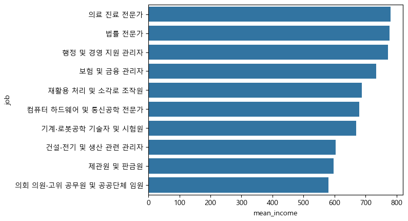

```python
# 막대 그래프 그리기
sns.barplot(data=top10, y='job', x='mean_income')
```

> (2) 월급이 적은 직업

```python
# 하위 10개 직업 추출
worst_mean_income_10 = job_income.sort_values('mean_income').head(10)
```

```python
worst_mean_income_10
```

|  | job | mean_income | 종사자수 | 최대월급 |
| --- | --- | --- | --- | --- |
| 33 | 기타 돌봄∙보건 및 개인 생활 서비스 종사자 | 73.964286 | 28 | 300.0 |
| 34 | 기타 서비스 관련 단순 종사자 | 77.789474 | 133 | 336.0 |
| 128 | 청소원 및 환경미화원 | 88.461756 | 353 | 417.0 |
| 0 | 가사 및 육아 도우미 | 92.455882 | 68 | 250.0 |
| 43 | 돌봄 및 보건 서비스 종사자 | 117.162338 | 154 | 274.0 |
| 97 | 음식 관련 단순 종사자 | 118.187500 | 112 | 358.0 |
| 39 | 농림∙어업 관련 단순 종사자 | 122.625000 | 24 | 215.0 |
| 139 | 학예사∙사서 및 기록물 관리사 | 140.000000 | 2 | 208.0 |
| 126 | 채굴 및 토목 관련 기능 종사자 | 140.000000 | 2 | 200.0 |
| 135 | 판매 관련 단순 종사자 | 140.909091 | 44 | 344.0 |

```
[(0.0, 800.0)]
```

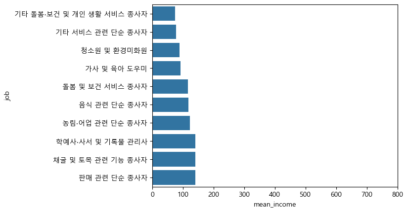

```python
# 막대 그래프 그리기 (상위 월급 직업군과 스케일을 맞추기 위해 x 범위를 0 ~ 800만원으로 조정
# sns.barplot(data=worst_mean_income_10, y='job', x='mean_income')
sns.barplot(data=worst_mean_income_10, y='job', x='mean_income').set(xlim=(0, 800))
```

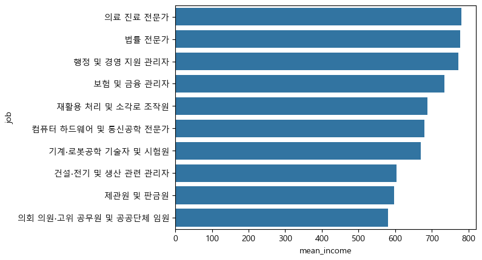

```python
sns.barplot(data=top10, y='job', x='mean_income')
```

> 데이터 분석
- '기타 돌봄∙보건 및 개인 생활 서비스 종사자'의 월급이 평균 73만원으로 가장 적고
- 월급이 가장 많은 '의료 진료 전문가' 평균 781만원과 비교하여 열배가 넘는 격차가 발생

# 9-7 성별 직업 빈도 - 성별로 어떤 직업이 가장 많을까?

## Lab 4 : 성별 직업 빈도 분석하기

## Lab 4 : 성별 직업 빈도 분석하기

1. 성별 직업 빈도표 만들기

```
result3.shape :  (148, 2)
```

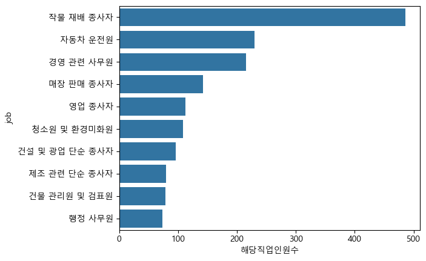

```python
result0 = welfare.dropna(subset = ['job'])
result1 = result0.query('sex == "male"')
result2 = result1.groupby('job', as_index = False)\
                    .agg(해당직업인원수 = ('job', 'count'))
result3 = result2.sort_values('해당직업인원수', ascending = False)
result3.head(5)
print("result3.shape : ", result3.shape)
sns.barplot(data = result3.head(10), y ='job', x= '해당직업인원수')
```

```python
# 남성 직업 빈도 상위 10개 추출
top10_job_male = welfare.dropna(subset=['job'])\
                .query('sex=="male"')\
                .groupby('job', as_index=False)\
                .agg(n=('job', 'count'))\
                .sort_values('n', ascending=False)\
                .head(10)
```

```python
top10_job_male
```

|  | job | n |
| --- | --- | --- |
| 107 | 작물 재배 종사자 | 486 |
| 104 | 자동차 운전원 | 230 |
| 11 | 경영 관련 사무원 | 216 |
| 46 | 매장 판매 종사자 | 142 |
| 89 | 영업 종사자 | 113 |
| 127 | 청소원 및 환경미화원 | 109 |
| 4 | 건설 및 광업 단순 종사자 | 96 |
| 120 | 제조 관련 단순 종사자 | 80 |
| 3 | 건물 관리원 및 검표원 | 79 |
| 141 | 행정 사무원 | 74 |

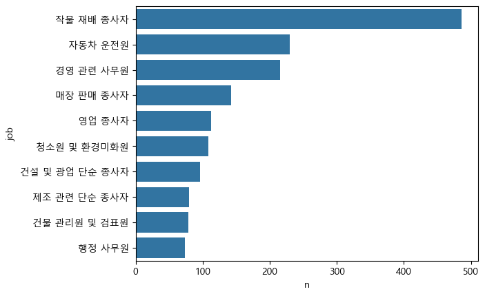

```python
sns.barplot(data = top10_job_male, y='job' , x='n')
```

```python
# 여성 직업 빈도 상위 10개 추출

top10_job_female = welfare.dropna(subset=['job'])\
                .query('sex=="female"')\
                .groupby('job', as_index=False)\
                .agg(n=('job', 'count'))\
                .sort_values('n', ascending=False)\
                .head(10)
```

```python
top10_job_female
```

|  | job | n |
| --- | --- | --- |
| 83 | 작물 재배 종사자 | 476 |
| 91 | 청소원 및 환경미화원 | 282 |
| 33 | 매장 판매 종사자 | 212 |
| 106 | 회계 및 경리 사무원 | 163 |
| 31 | 돌봄 및 보건 서비스 종사자 | 155 |
| 87 | 제조 관련 단순 종사자 | 148 |
| 73 | 음식 관련 단순 종사자 | 126 |
| 58 | 식음료 서비스 종사자 | 117 |
| 88 | 조리사 | 114 |
| 24 | 기타 서비스 관련 단순 종사자 | 97 |

2. 그래프 만들기

```
[(0.0, 500.0)]
```

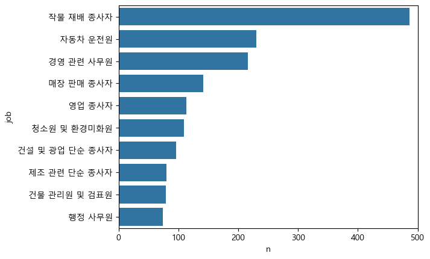

```python
# 남성 직업 빈도 막대 그래프 만들기
sns.barplot(data=top10_job_male, x='n', y='job').set(xlim = (0, 500))
```

```
[(0.0, 500.0)]
```

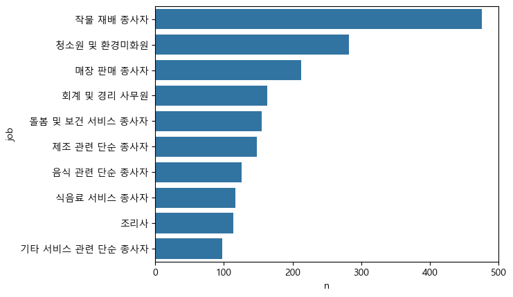

```python
# 여성 직업 빈도 막대 그래프 만들기
sns.barplot(data=top10_job_female, x='n', y='job').set(xlim = (0, 500))
```

# 9-8 종교 유무에 따른 이혼율 - 종교가 있으면 이혼을 덜할까?

## Lab 5 : 종교 변수 검토 및 전처리하기

## Lab 6 : 혼인상태 변수 검토 및 전처리하기

## Lab 7 : 종교 유무에 따른 이혼율 분석하기

## Lab 8 : 연령대 및 종교 유무에 따른 이혼율 분석하기

## Lab 5 : 종교 변수 검토 및 전처리하기

- religion 변수 상태 검토
1. 변수 검토하기

```python
# 종교 변수 타입 출력
welfare['religion'].dtypes
```

```
dtype('float64')
```

```python
# 종교 별 빈도 구하기
welfare['religion'].value_counts()
```

```
religion
2.0    7815
1.0    6603
Name: count, dtype: int64
```

> 종교 값이 코드화 되어 있음 (무응답(9)은 없음)

| 값 | 내용 |
| --- | --- |
| 1 | 있음 |
| 2 | 없음 |
| 9 | 무응답 |

2. 전처리
- 종교가 있으면(1) 'yes', 없으면(2) 'no'로 변환

```python
#9가 있으면  np.nan으로 바꾼다.
welfare['religion'] = np.where( welfare['religion'] == 9 , np.nan, welfare['religion'] )
```

```python
welfare['religion'].isna().sum()
```

```
0
```

```python
welfare['religion'].head()
```

```
0    1.0
1    2.0
2    1.0
3    1.0
4    1.0
Name: religion, dtype: float64
```

```python
# 종교 유무에 있을경우에 'yes', 없을 경우에는 'no'
welfare['religion'] = np.where(welfare['religion'] == 1, 'yes', 'no')
```

```python
welfare['religion'].head()
```

```
0    yes
1     no
2    yes
3    yes
4    yes
Name: religion, dtype: object
```

```python
# 빈도 구하기
welfare['religion'].value_counts()
```

```
religion
no     7815
yes    6603
Name: count, dtype: int64
```

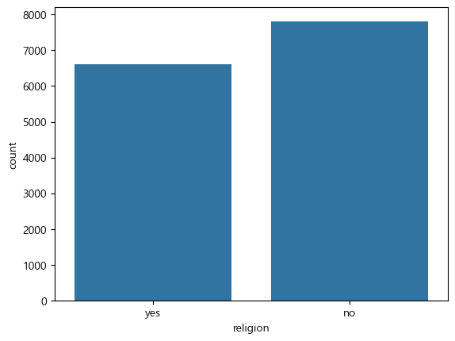

```python
# 막대 그래프 그리기
sns.countplot(data=welfare, x='religion')
```

## Lab 6 : 혼인상태 변수 검토 및 전처리하기

- marriage_type 변수 검토
1. 변수 검토하기

```python
# 변수 타입 출력
welfare['marriage_type'].dtypes
```

```
dtype('float64')
```

```python
# 결홍 유형에 따른 빈도수 출력
welfare['marriage_type'].value_counts()
```

```
marriage_type
1.0    7190
5.0    2357
0.0    2121
2.0    1954
3.0     689
4.0      78
6.0      29
Name: count, dtype: int64
```

> marriage_type이 0, 1, 2, 3, 4, 5, 6까지 7개 유형이 있음을 알 수 있다

| 값 | 내용 |
| --- | --- |
| 0 | 해당 없음(18세 미만) |
| 1 | 유배우 |
| 2 | 사별 |
| 3 | 이혼 |
| 4 | 별거 |
| 5 | 미혼(18세 이상, 미혼모 포함 |
| 6 | 기타(사망 등) |

2. 파생변수 만들기 - 이혼 여부
- marriage_type (1) : 결혼
- marriage_type (3) : 이혼
- marriage_type (0, 2, 4, 5, 6) : 기타

```python
# 이혼 여부 변수 만들기
welfare['marriage'] = np.where(welfare['marriage_type'] == 1, 'marriage',
                      np.where(welfare['marriage_type'] == 3, 'divorce',
                                                          'etc'))
```

```python
# 이혼 여부별 빈도
n_divorce = welfare.groupby('marriage', as_index = False) \
                    .agg(n = ('marriage', 'count'))
```

```python
n_divorce
```

|  | marriage | n |
| --- | --- | --- |
| 0 | divorce | 689 |
| 1 | etc | 6539 |
| 2 | marriage | 7190 |

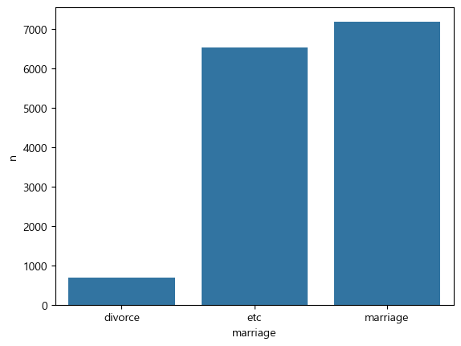

```python
# 막대 그래프 그리기
sns.barplot(data=n_divorce, x='marriage', y='n')
```

## Lab 7 : 종교 유무에 따른 이혼율 분석하기

1. 종교 유무에 따른 이혼율 표 만들기

```python
#1) groupby를 두개의 column으로
rel_div1 = welfare.query('marriage != "etc"') \
                .groupby(['religion', 'marriage'], as_index = False)\
                .agg( n =('religion', 'count'))
rel_div1
```

|  | religion | marriage | n |
| --- | --- | --- | --- |
| 0 | no | divorce | 384 |
| 1 | no | marriage | 3660 |
| 2 | yes | divorce | 305 |
| 3 | yes | marriage | 3530 |

```python
df_groupby = welfare.query('marriage != "etc"') \
                .groupby('religion', as_index = False)
df_groupby
```

```
<pandas.core.groupby.generic.DataFrameGroupBy object at 0x000001BA2F6BB050>
```

```python
#2) groupby는 하나의 column 으로, value_counts()
rel_div2 = welfare.query('marriage != "etc"') \
                .groupby('religion', as_index = False)['marriage']\
                .value_counts()
rel_div2
```

|  | religion | marriage | count |
| --- | --- | --- | --- |
| 0 | no | marriage | 3660 |
| 1 | no | divorce | 384 |
| 2 | yes | marriage | 3530 |
| 3 | yes | divorce | 305 |

```python
#3) normalize = True
rel_div3 = welfare.query('marriage != "etc"') \
                .groupby('religion', as_index = False)['marriage']\
                .value_counts(normalize = True)
rel_div3
```

|  | religion | marriage | proportion |
| --- | --- | --- | --- |
| 0 | no | marriage | 0.905045 |
| 1 | no | divorce | 0.094955 |
| 2 | yes | marriage | 0.920469 |
| 3 | yes | divorce | 0.079531 |

# 다른 컬럼을 더 추가하고 싶을때는?

```python
#다른 column도 뽑아낼수 있다. normalize = True 옵션을 줄수 있다.
rel_div10 = welfare.query('marriage != "etc"')\
                    .groupby(['religion'], as_index = False)['ageg']\
                        .value_counts(normalize = True)

rel_div11 = welfare.query('marriage != "etc"')\
                    .groupby(['religion'], as_index = False)['marriage']\
                        .value_counts()

rel_div12 = welfare.query('marriage != "etc"')\
                    .groupby(['religion'], as_index = False)['sex']\
                        .value_counts()
rel_div13 = welfare.query('marriage != "etc"')\
                    .groupby(['religion'], as_index = False)['marriage_type']\
                        .value_counts()
rel_div12
```

|  | religion | sex | count |
| --- | --- | --- | --- |
| 0 | no | male | 2183 |
| 1 | no | female | 1861 |
| 2 | yes | female | 2115 |
| 3 | yes | male | 1720 |

2. 그래프 만들기

```python
rel_div3
```

|  | religion | marriage | proportion |
| --- | --- | --- | --- |
| 0 | no | marriage | 0.905045 |
| 1 | no | divorce | 0.094955 |
| 2 | yes | marriage | 0.920469 |
| 3 | yes | divorce | 0.079531 |

```python
rel_div = rel_div3.query('marriage == "divorce"') \
                .assign(proportion = rel_div3['proportion']*100) \
                .round(1)
rel_div
```

|  | religion | marriage | proportion |
| --- | --- | --- | --- |
| 1 | no | divorce | 9.5 |
| 3 | yes | divorce | 8.0 |

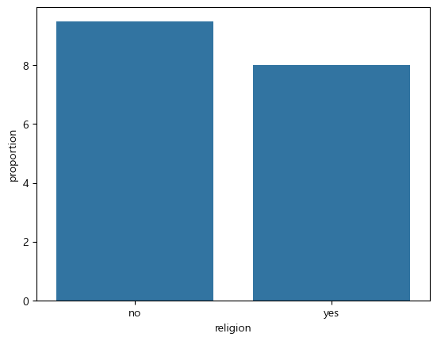

```python
sns.barplot(data=rel_div, x='religion', y='proportion')
```

> 종교가 있는 경우 이혼율 8.0%, 종교가 없는 경우 이혼율 9.5% (의미 잇는 차이 인가 ?)

## Lab 8 : 연령대 및 종교 유무에 따른 이혼율 분석하기

```python
welfare.query('marriage != "etc"') \
                .groupby('ageg', as_index=False) \
                ['marriage'] \
                .value_counts()
```

|  | ageg | marriage | count |
| --- | --- | --- | --- |
| 0 | middle | marriage | 3552 |
| 1 | middle | divorce | 350 |
| 2 | old | marriage | 3581 |
| 3 | old | divorce | 336 |
| 4 | young | marriage | 57 |
| 5 | young | divorce | 3 |

1. 연령대 별 이혼율 표 만들기

```python
age_div = welfare.query('marriage != "etc"') \
                .groupby('ageg', as_index=False) \
                ['marriage'] \
                .value_counts(normalize = True)
age_div
```

|  | ageg | marriage | proportion |
| --- | --- | --- | --- |
| 0 | middle | marriage | 0.910302 |
| 1 | middle | divorce | 0.089698 |
| 2 | old | marriage | 0.914220 |
| 3 | old | divorce | 0.085780 |
| 4 | young | marriage | 0.950000 |
| 5 | young | divorce | 0.050000 |

> 초년층은 사례가 부족하여 분석 작업에서 제외
2. 연령대별 이혼율 그래프 그리기

```python
age_div = age_div.query('ageg != "young" & marriage == "divorce"')\
                    .assign(proportion = age_div['proportion'] * 100)\
                    .round(1)
age_div
```

|  | ageg | marriage | proportion |
| --- | --- | --- | --- |
| 1 | middle | divorce | 9.0 |
| 3 | old | divorce | 8.6 |

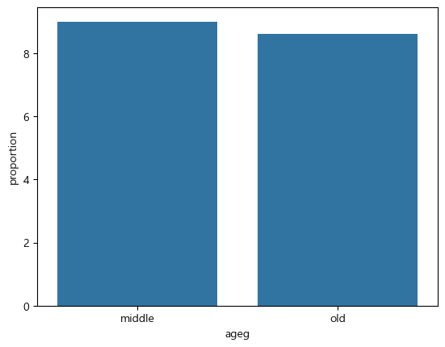

```python
# 막대 그래프 만들기
sns.barplot(data=age_div, x='ageg', y='proportion')
```

3. 연령대 및 종교 유무에 따른 이혼율표 만들기
- 분석에서 초년층 제외

```python
age_rel_div = welfare.query('marriage != "etc" & ageg != "young"') \
                    .groupby(['ageg', 'religion'], as_index=False) \
                    ['marriage'] \
                    .value_counts(normalize=True)
age_rel_div
```

|  | ageg | religion | marriage | proportion |
| --- | --- | --- | --- | --- |
| 0 | middle | no | marriage | 0.904953 |
| 1 | middle | no | divorce | 0.095047 |
| 2 | middle | yes | marriage | 0.917520 |
| 3 | middle | yes | divorce | 0.082480 |
| 4 | old | no | marriage | 0.904382 |
| 5 | old | no | divorce | 0.095618 |
| 6 | old | yes | marriage | 0.922222 |
| 7 | old | yes | divorce | 0.077778 |

4. 연령대 및 종교 유무에 따른 이혼율 그래프 만들기

```python
age_rel_div = \
    age_rel_div.query('marriage == "divorce"') \
                .assign(proportion = age_rel_div['proportion']*100) \
                .round(1)
age_rel_div
```

|  | ageg | religion | marriage | proportion |
| --- | --- | --- | --- | --- |
| 1 | middle | no | divorce | 9.5 |
| 3 | middle | yes | divorce | 8.2 |
| 5 | old | no | divorce | 9.6 |
| 7 | old | yes | divorce | 7.8 |

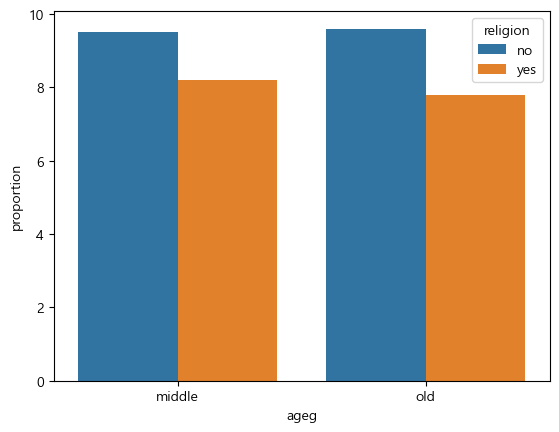

```python
# 막대 그래프 그리기
sns.barplot(data=age_rel_div, x='ageg', y='proportion', hue='religion')
```

# 9-9 지역별 연령대 비율 - 어느 지역에 노년층이 많을까?

## Lab 9 : 지역변수 검토 및 전처리

## Lab 10 : 지역별 연령대 비율 분석하기

## Lab 9 : 지역변수 검토 및 전처리

1. 변수 검토하기

```python
welfare['code_region'].dtypes
```

```
dtype('float64')
```

```python
welfare['code_region'].value_counts()
```

```
code_region
2.0    3246
7.0    2466
3.0    2448
1.0    2002
4.0    1728
5.0    1391
6.0    1137
Name: count, dtype: int64
```

| 값 | 내용 |
| --- | --- |
| 1 | 서울 |
| 2 | 수도권(인천, 경기) |
| 3 | 부산/경남/울산 |
| 4 | 대구/경북 |
| 5 | 대전/충남 |
| 6 | 강원/충북 |
| 7 | 광주/전남/전북/제주도 |

2. 전처리 하기

```python
# 지역 코드 목록 만들기
list_region = pd.DataFrame({'code_region' : [1, 2, 3, 4, 5, 6, 7],
                             'region' : ['서울',
                                         '수도권(인천,경기)',
                                         '부산/경남/울산',
                                          '대구/경북',
                                          '대전/충남',
                                           '강원/충북',
                                           '광주/전남/전북/제주도']})
list_region
```

|  | code_region | region |
| --- | --- | --- |
| 0 | 1 | 서울 |
| 1 | 2 | 수도권(인천,경기) |
| 2 | 3 | 부산/경남/울산 |
| 3 | 4 | 대구/경북 |
| 4 | 5 | 대전/충남 |
| 5 | 6 | 강원/충북 |
| 6 | 7 | 광주/전남/전북/제주도 |

```python
# 지역명 추가
welfare = welfare.merge(list_region, how='left', on='code_region')
welfare[['code_region', 'region']].head()
```

|  | code_region | region |
| --- | --- | --- |
| 0 | 1.0 | 서울 |
| 1 | 1.0 | 서울 |
| 2 | 1.0 | 서울 |
| 3 | 1.0 | 서울 |
| 4 | 1.0 | 서울 |

## Lab 10 : 지역별 연령대 비율 분석하기

1. 지역별 연령대 비율표 만들기

```python
region_ageg = welfare.groupby('region', as_index=False) \
                    ['ageg'] \
                    .value_counts(normalize=True)
region_ageg
```

|  | region | ageg | proportion |
| --- | --- | --- | --- |
| 0 | 강원/충북 | old | 0.459103 |
| 1 | 강원/충북 | middle | 0.308707 |
| 2 | 강원/충북 | young | 0.232190 |
| 3 | 광주/전남/전북/제주도 | old | 0.449311 |
| 4 | 광주/전남/전북/제주도 | middle | 0.317924 |
| 5 | 광주/전남/전북/제주도 | young | 0.232766 |
| 6 | 대구/경북 | old | 0.504051 |
| 7 | 대구/경북 | middle | 0.296296 |
| 8 | 대구/경북 | young | 0.199653 |
| 9 | 대전/충남 | old | 0.413372 |
| 10 | 대전/충남 | middle | 0.336449 |
| 11 | 대전/충남 | young | 0.250180 |
| 12 | 부산/경남/울산 | old | 0.437500 |
| 13 | 부산/경남/울산 | middle | 0.333742 |
| 14 | 부산/경남/울산 | young | 0.228758 |
| 15 | 서울 | middle | 0.385115 |
| 16 | 서울 | old | 0.376124 |
| 17 | 서울 | young | 0.238761 |
| 18 | 수도권(인천,경기) | middle | 0.388170 |
| 19 | 수도권(인천,경기) | old | 0.325015 |
| 20 | 수도권(인천,경기) | young | 0.286815 |

2. 그래프 만들기

```python
region_ageg = \
  region_ageg.assign(proportion = region_ageg['proportion'] * 100) \
            .round(1)
region_ageg
```

|  | region | ageg | proportion |
| --- | --- | --- | --- |
| 0 | 강원/충북 | old | 45.9 |
| 1 | 강원/충북 | middle | 30.9 |
| 2 | 강원/충북 | young | 23.2 |
| 3 | 광주/전남/전북/제주도 | old | 44.9 |
| 4 | 광주/전남/전북/제주도 | middle | 31.8 |
| 5 | 광주/전남/전북/제주도 | young | 23.3 |
| 6 | 대구/경북 | old | 50.4 |
| 7 | 대구/경북 | middle | 29.6 |
| 8 | 대구/경북 | young | 20.0 |
| 9 | 대전/충남 | old | 41.3 |
| 10 | 대전/충남 | middle | 33.6 |
| 11 | 대전/충남 | young | 25.0 |
| 12 | 부산/경남/울산 | old | 43.8 |
| 13 | 부산/경남/울산 | middle | 33.4 |
| 14 | 부산/경남/울산 | young | 22.9 |
| 15 | 서울 | middle | 38.5 |
| 16 | 서울 | old | 37.6 |
| 17 | 서울 | young | 23.9 |
| 18 | 수도권(인천,경기) | middle | 38.8 |
| 19 | 수도권(인천,경기) | old | 32.5 |
| 20 | 수도권(인천,경기) | young | 28.7 |

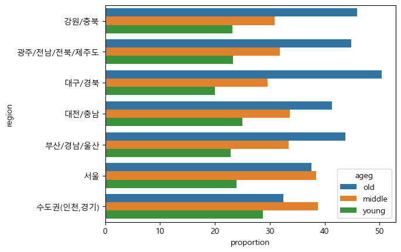

```python
# 막대 그래프 만들기
sns.barplot(data=region_ageg, y='region', x='proportion', hue='ageg')
```

3. 누적 막대그래프 만들기

> (1) 피벗하기
> > - index : 'region' 컬럼의 유일한 값들을 index로 변경한다. (서울, 수도권, 강원, 경북, 전남 등등 )
> > - columns : 'ageg' 컬럼의 유일한 값들을 column으로 변경한다. (young, middle, old)
> > - values : 'proportion' 컬럼의 값들을 실제 값에 넣어준다.

```python
region_ageg.head(10)
```

|  | region | ageg | proportion |
| --- | --- | --- | --- |
| 0 | 강원/충북 | old | 45.9 |
| 1 | 강원/충북 | middle | 30.9 |
| 2 | 강원/충북 | young | 23.2 |
| 3 | 광주/전남/전북/제주도 | old | 44.9 |
| 4 | 광주/전남/전북/제주도 | middle | 31.8 |
| 5 | 광주/전남/전북/제주도 | young | 23.3 |
| 6 | 대구/경북 | old | 50.4 |
| 7 | 대구/경북 | middle | 29.6 |
| 8 | 대구/경북 | young | 20.0 |
| 9 | 대전/충남 | old | 41.3 |

```python
pivot_df = region_ageg.pivot(index = 'region',\
                             columns = 'ageg',\
                             values = 'proportion')
pivot_df
```

| ageg region | middle | old | young |
| --- | --- | --- | --- |
| 강원/충북 | 30.9 | 45.9 | 23.2 |
| 광주/전남/전북/제주도 | 31.8 | 44.9 | 23.3 |
| 대구/경북 | 29.6 | 50.4 | 20.0 |
| 대전/충남 | 33.6 | 41.3 | 25.0 |
| 부산/경남/울산 | 33.4 | 43.8 | 22.9 |
| 서울 | 38.5 | 37.6 | 23.9 |
| 수도권(인천,경기) | 38.8 | 32.5 | 28.7 |

> (1) 그래프 만들기

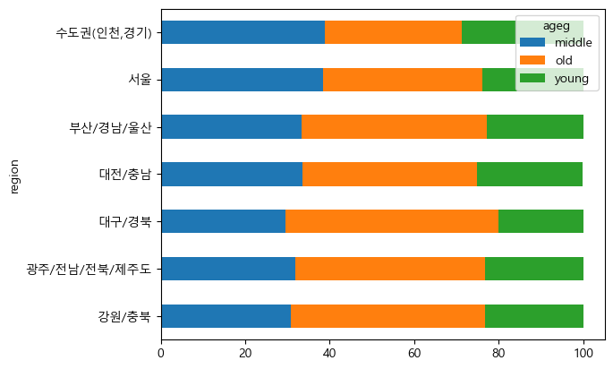

```python
pivot_df.plot.barh(stacked = True)
```

```python
reorder_df = pivot_df.sort_values('old')[['young', 'middle','old']]
reorder_df
```

| ageg region | young | middle | old |
| --- | --- | --- | --- |
| 수도권(인천,경기) | 28.7 | 38.8 | 32.5 |
| 서울 | 23.9 | 38.5 | 37.6 |
| 대전/충남 | 25.0 | 33.6 | 41.3 |
| 부산/경남/울산 | 22.9 | 33.4 | 43.8 |
| 광주/전남/전북/제주도 | 23.3 | 31.8 | 44.9 |
| 강원/충북 | 23.2 | 30.9 | 45.9 |
| 대구/경북 | 20.0 | 29.6 | 50.4 |

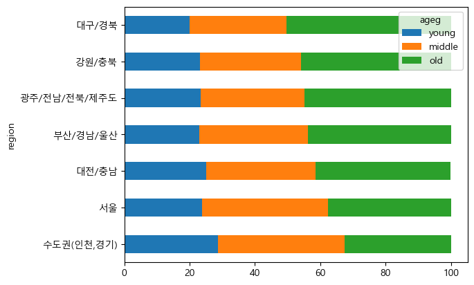

```python
reorder_df.plot.barh(stacked = True)
```